# Pathway analysis with QuSAGE: Meta-analysis of medulloblastoma

J. Taroni for ALSF CCDL

2019

## Background

The Quantitative Set Analysis of Gene Expression (QuSAGE) ([Yaari et al. *NAR*. 2013.](https://doi.org/10.1093/nar/gkt660)) framework has advantages that we outline in `qusage_single_dataset`, including the fact that it returns more than just a p-value. Specifically, QuSAGE quantifies gene set activity with a full probability density function (PDF). If we’re interested in pathway analysis of multiple datasets, QuSAGE allows us to perform a *meta-analysis* by combining distributions from the QuSAGE results from each dataset. Meta-analysis with QuSAGE is described in [Meng et al. *PLoS Comp Bio.* 2019.](https://doi.org/10.1371/journal.pcbi.1006899) and implemented in the [`qusage` bioconductor package](https://bioconductor.org/packages/release/bioc/html/qusage.html). The [`qusage` vignette](https://bioconductor.org/packages/release/bioc/vignettes/qusage/inst/doc/qusage.pdf) contains a section on meta-analysis.

## Datasets

We will use two medulloblastoma datasets— [Northcott et al.](https://doi.org/10.1038/nature11327) and [Robinson et al.](https://doi.org/10.1038/nature11213)—to demonstrate how to perform meta-analysis with `qusage`. Specifically, we’ll identify pathways that are differentially active between the SHH subgroup vs. the Group 3 and 4 subgroups in both datasets. These datasets are [`GSE37382`](https://www.refine.bio/experiments/GSE37382/subgroup-specific-somatic-copy-number-aberrations-in-the-medulloblastoma-genome-mrna) and [`GSE37418`](https://www.refine.bio/experiments/GSE37418/novel-mutations-target-distinct-subgroups-of-medulloblastoma), respectively.

## Set up

### Package installation and loading

```r
if (!("qusage" %in% installed.packages())) {
  BiocManager::install("qusage", update = FALSE)
}

if (!("org.Hs.eg.db" %in% installed.packages())) {
  BiocManager::install("org.Hs.eg.db", update = FALSE)
}
```

```r
`%>%` <- dplyr::`%>%`
```

```r
library(org.Hs.eg.db)
library(qusage)
```

### Directories

Make directories to hold the plots and results if they do not yet exist.

```r
# Define the file path to the plots directory
plots_dir <- "plots"  # Replace with path to desired output plots directory

# Make a plots directory if it isn't created yet
if (!dir.exists(plots_dir)) {
  dir.create(plots_dir)
}

# Define the file path to the results directory
results_dir <- "results"  # Replace with path to desired output results directory

# Make a results directory if it isn't created yet
if (!dir.exists(results_dir)) {
  dir.create(results_dir)
}

# Define the file path to the data directory
data_dir <- "data"
```

### Function

Function to perform gene identifier conversion – we’ll do this once for each dataset. We ‘functionalize’ it to keep from repeating ourselves. For an example where we do the conversion without using a custom function, see `qusage_single_dataset` or `qusage_replicate_vignette`.

```r
convert_ensembl_to_entrez_mat <- function(exprs_df) {
  # Given a data.frame that contains human gene expression values and a column
  # (named ENSEMBL) that contains Ensembl gene IDs, return an expression matrix
  # where the rownames are Entrez IDs. In the case of duplicate Entrez
  # identifiers, we summarize to the mean value for an Entrez ID. Mapping
  # is performed with AnnotationDbi::mapIDs.
  #
  # Args:
  #   exprs_df: A data.frame of gene expression data. The first column should be
  #             named ENSEMBL and contain Ensembl gene IDs. Rows are genes;
  #             columns are samples.
  # Returns:
  #   An expression matrix where the rownames are Entrez gene IDs

  `%>%` <- dplyr::`%>%`
  require(org.Hs.eg.db)

  # error-handling: we need an ENSEMBL column
  if (!("ENSEMBL" %in% colnames(exprs_df))) {
    stop("'ENSEMBL' column expected in exprs_df")
  }

  # using the default behavior for 1:many mappings, where only the first one is
  # selected
  entrez_mappings <- mapIds(org.Hs.eg.db, keys = exprs_df$ENSEMBL,
                            column = "ENTREZID", keytype = "ENSEMBL")

  # if this is not returned in the same order as the keys for some reason, stop
  if (!all.equal(names(entrez_mappings), exprs_df$ENSEMBL)) {
    stop("Something happened to the gene order!")
  }

  # annotation with Entrez IDs
  entrez_exprs_df <- exprs_df %>%
    # add a new column that contains the Entrez IDs
    # this gets added as the last column
    dplyr::mutate(ENTREZID = entrez_mappings) %>%
    # drop the Ensembl gene IDs
    dplyr::select(-ENSEMBL) %>%
    # reorder such that the Entrez IDs are in the first column
    dplyr::select(ENTREZID, dplyr::everything()) %>%
    # drop any genes without an Entrez ID
    dplyr::filter(!is.na(ENTREZID))

  # if there are any duplicate Entrez gene IDs, collapse to the mean value
  if (any(duplicated(entrez_exprs_df$ENTREZID))) {
    message("Collapsing to mean value...")
    entrez_exprs_df <- entrez_exprs_df %>%
      dplyr::group_by(ENTREZID) %>%
      dplyr::summarise_all(mean)
  }

  # expression matrix where the rownames are the gene identifiers
  exprs_mat <- entrez_exprs_df %>%
    tibble::column_to_rownames("ENTREZID") %>%
    as.matrix()

}
```

### Gene sets

`qusage` allows you to read in gene sets that are in the [GMT format](http://software.broadinstitute.org/cancer/software/gsea/wiki/index.php/Data_formats#GMT:_Gene_Matrix_Transposed_file_format_.28.2A.gmt.29). [MSigDB](http://software.broadinstitute.org/gsea/msigdb) offers gene sets in this format.

For more information or recommendations about gene sets, [see the **Gene Sets** section of the module README](https://github.com/AlexsLemonade/refinebio-examples/tree/master/pathway-analysis#choosing-gene-sets).

We need to download the the MSigDB v6.2 KEGG gene sets that use Entrez gene IDs and place them at the following relative path:

```
gene-sets/c2.cp.kegg.v6.2.entrez.gmt
```

We can download the file if it’s not available locally yet.

```r
# the kegg gmt file should be located in the spot we mention above
kegg_file <- file.path("gene-sets", "c2.cp.kegg.v6.2.entrez.gmt")
# since we do not track this file in our repository, let's check to make sure
# it exists where we expect it and download it if we don't find it
if (!file.exists(kegg_file)) {
  message(paste("KEGG GMT file is not found at", kegg_file,
                ", downloading now..."))
  # need gene-sets directory
  if (!dir.exists("gene-sets")) {
    dir.create("gene-sets")
  }
  download.file("https://data.broadinstitute.org/gsea-msigdb/msigdb/release/6.2/c2.cp.kegg.v6.2.entrez.gmt",
                destfile = kegg_file)
}
```

## Read in and prep refine.bio data

### Northcott et al.

This dataset is too large to be tracked with git without compression. We need to unzip it here if we have not already.

```r
# if the unzipped folder does not exist
if (!dir.exists(file.path(data_dir,
                          "GSE37382" # Replace with the name of your file without the .zip extension
                          ))) {
  compressed_file <- file.path(data_dir,
                               "GSE37382.zip" # Replace with the name of zipped your file
                               )
  unzip(compressed_file, exdir = data_dir)
}
```

#### Expression data

```r
northcott_expression_file <- file.path(data_dir,
                                       "GSE37382", # Replace with name of your unzipped folder
                                       "GSE37382.tsv" # Replace with name of your expression file
                                       )
northcott_exprs_df <- readr::read_tsv(northcott_expression_file,
                                      progress = FALSE)
# first column is currently named 'Gene' and contains Ensembl gene IDs
colnames(northcott_exprs_df)[1] <- "ENSEMBL"
```

Convert to expression matrix that uses Entrez IDs as rownames using a custom function.

```r
northcott_mat <- convert_ensembl_to_entrez_mat(northcott_exprs_df)
```

```
Collapsing to mean value...
```

We no longer need the `data.frame` that contains the expression values.

```r
rm(northcott_exprs_df)
```

#### Metadata

```r
northcott_metadata_file <- file.path(data_dir,
                                     "GSE37382", # Replace with name of your unzipped folder
                                     "metadata_GSE37382.tsv" # Replace with name of your metadata file
                                     )
northcott_metadata_df <- readr::read_tsv(northcott_metadata_file) %>%
  # drop columns that are all NA
  dplyr::select(-which(apply(is.na(.), 2, all)))
```

We’re going to compare the SHH subgroup to all others, so we need to encode this information in a new column (`shh_v_other`).

```r
northcott_metadata_df <- northcott_metadata_df %>%
  # retain only pertinent columns
  dplyr::select(refinebio_accession_code, refinebio_title, refinebio_age,
                refinebio_sex, subgroup) %>%
  # new column that sets up pathway analysis
  dplyr::mutate(shh_v_other = dplyr::case_when(
    subgroup != "SHH" ~ "Other",
    TRUE ~ "SHH"
  ))
```

Reorder expression matrix to match the metadata.

```r
northcott_mat <- northcott_mat[, northcott_metadata_df$refinebio_accession_code]
```

### Robinson et al.

#### Expression data

```r
robinson_expression_file <- file.path(data_dir,
                                      "GSE37418", # Replace with name of unzipped folder containing the second expression file
                                      "GSE37418.tsv" # Replace with name of your second expression file
                                      )
robinson_exprs_df <- readr::read_tsv(robinson_expression_file,
                                     progress = FALSE)
colnames(robinson_exprs_df)[1] <- "ENSEMBL"
```

Convert to expression matrix that uses Entrez IDs as rownames using a custom function.

```r
robinson_mat <- convert_ensembl_to_entrez_mat(robinson_exprs_df)
```

```
Collapsing to mean value...
```

```r
rm(robinson_exprs_df)
```

#### Metadata

```r
robinson_metadata_file <- file.path(data_dir,
                                    "GSE37418", # Replace with name of unzipped folder containing the second expression file data
                                    "metadata_GSE37418.tsv" # Replace with name of the metadata file relevant to your second expression file
                                    )
robinson_metadata_df <- readr::read_tsv(robinson_metadata_file) %>%
  # drop columns that are all NA
  dplyr::select(-which(apply(is.na(.), 2, all)))
```

To make this more comparable to the Northcott et al. dataset, we’re going to remove the WNT subgroup and outliers such that we are comparing the SHH group to Group 3 and Group 4.

```r
robinson_metadata_df <- robinson_metadata_df %>%
  # retain only pertinent columns
  dplyr::select(refinebio_accession_code, refinebio_title, age, `m stage`,
                subgroup) %>%
  # make more comparable to Northcott dataset
  dplyr::filter(!(subgroup %in% c("WNT", "SHH OUTLIER", "U"))) %>%
  # we'll use SHH vs. Other for our pathway analysis
  dplyr::mutate(shh_v_other = dplyr::case_when(
    subgroup != "SHH" ~ "Other",
    TRUE ~ "SHH"
  ))
```

Reorder expression data to match metadata.

```r
robinson_mat <- robinson_mat[, robinson_metadata_df$refinebio_accession_code]
```

## Pathway analysis

### Read in KEGG pathways

```r
kegg_pathways <- read.gmt(kegg_file)
```

### Northcott et al.

```r
northcott_results <- qusage(eset = northcott_mat,
                            labels = northcott_metadata_df$shh_v_other,
                            contrast = "SHH-Other",
                            geneSets = kegg_pathways)
```

```
Aggregating gene data for gene sets......................................Done.
Calculating variance inflation factors...Done.
```

Save the Northcott et al. results to file.

```r
northcott_results_file <- file.path(results_dir,
                                    "Northcott_SHH-Other_QSarray.RDS" # Replace with a relevant output name for the first results RDS file
                                    )
readr::write_rds(northcott_results, northcott_results_file)
```

### Robinson et al.

```r
robinson_results <- qusage(eset = robinson_mat,
                           labels = robinson_metadata_df$shh_v_other,
                           contrast = "SHH-Other",
                           geneSets = kegg_pathways)
```

```
Aggregating gene data for gene sets......................................Done.
Calculating variance inflation factors...Done.
```

Save the Robinson et al. results to file.

```r
robinson_results_file <- file.path(results_dir,
                                   "Robinson_SHH-Other_QSarray.RDS" # Replace with a relevant output name for the second results RDS file
                                   )
readr::write_rds(robinson_results, robinson_results_file)
```

## Meta-analysis

### Combine probability density function

`combinePDFs` is a `qusage` function we can use for meta-analysis. This function accepts a list of `QSArray` results.

```r
results_list <- list(
  Northcott = northcott_results,
  Robinson = robinson_results
)
```

Because there are more samples in the Northcott et al. dataset, it will be weighted more highly when combining the distribution.

```r
combined_results <- combinePDFs(results_list)
```

Just as in a single dataset, we can extract relevant information from the combined `QSArray` with built-in `qusage` functions.

Let’s look at the top 20 pathways with `qsTable`. The row numbers in the output of `qsTable` can serve as input to the `path.index` argument of other `qusage` functions as we’ll see below.

```r
qsTable(combined_results)
```

|  | pathway.name | log.fold.change | p.Value | FDR |
| --- | --- | --- | --- | --- |
| 162 | KEGG_PATHWAYS_IN_CANCER | 0.5561149 | 4.526788e-13 | 2.713674e-11 |
| 91 | KEGG_PHOSPHATIDYLINOSITOL_SIGNALING_SYSTEM | -0.7428668 | 8.879564e-13 | 2.713674e-11 |
| 92 | KEGG_NEUROACTIVE_LIGAND_RECEPTOR_INTERACTION | -0.3111271 | 9.023893e-13 | 2.713674e-11 |
| 107 | KEGG_DORSO_VENTRAL_AXIS_FORMATION | -0.6908559 | 9.263701e-13 | 2.713674e-11 |
| 174 | KEGG_ACUTE_MYELOID_LEUKEMIA | -0.7745653 | 9.880985e-13 | 2.713674e-11 |
| 146 | KEGG_ADIPOCYTOKINE_SIGNALING_PATHWAY | -0.3631126 | 1.200151e-12 | 2.713674e-11 |
| 131 | KEGG_FC_EPSILON_RI_SIGNALING_PATHWAY | -0.4280458 | 1.221245e-12 | 2.713674e-11 |
| 147 | KEGG_TYPE_II_DIABETES_MELLITUS | -1.1747357 | 1.284084e-12 | 2.713674e-11 |
| 126 | KEGG_JAK_STAT_SIGNALING_PATHWAY | -0.5501838 | 1.393552e-12 | 2.713674e-11 |
| 41 | KEGG_GLYCOSYLPHOSPHATIDYLINOSITOL_GPI_ANCHOR_BIOSYNTHESIS | -0.8366180 | 1.491030e-12 | 2.713674e-11 |

[output cut: 10 more lines]

### Plotting

We can plot the distributions with `plotCombinedPDF`. First let’s plot KEGG Pathways in Cancer, which has elevated expression in the SHH group as it has a *positive* fold change. In a two group comparison in QuSAGE, **pathway activity** is the mean difference of the log expression of all genes in a pathway.

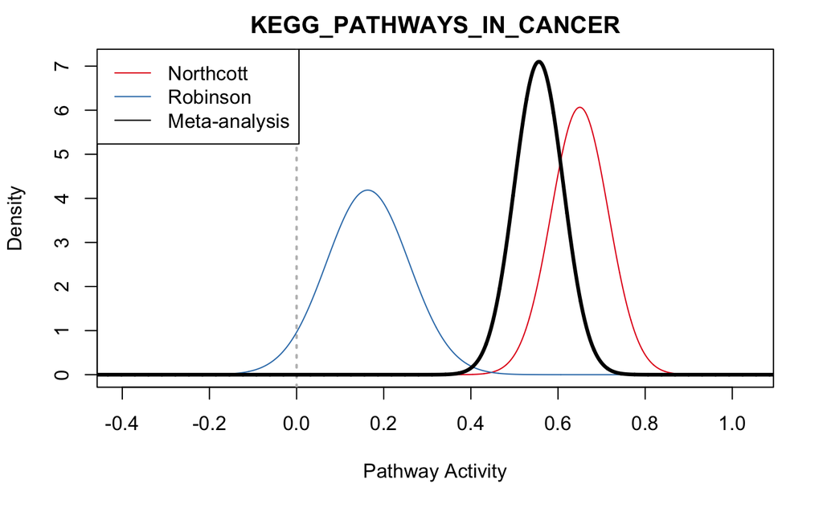

```r
plotCombinedPDF(combined_results, path.index = 162)
legend("topleft", legend = c("Northcott", "Robinson", "Meta-analysis"),
       lty = 1, col = c("#E41A1C", "#377EB8", "black"))
```

Let’s plot KEGG Dorsoventral Axis Formation, which has higher expression in Group 3 and 4 samples.

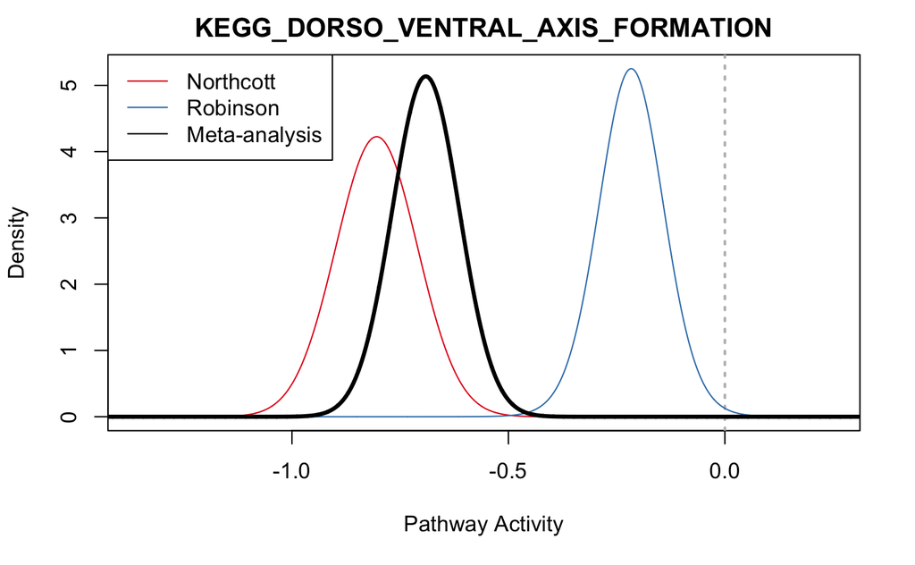

```r
plotCombinedPDF(combined_results, path.index = 107)
legend("topleft", legend = c("Northcott", "Robinson", "Meta-analysis"),
       lty = 1, col = c("#E41A1C", "#377EB8", "black"))
```

#### Plot individual gene mean and 95% confidence intervals (CI)

We know that the directionality of the KEGG Dorsoventral Axis Formation pathway agrees between datasets. We can look into what genes are driving the pathway activity with the `plotCIsGenes` function. Gene activity, which will be plotted on the y-axis, is difference between the two groups. The *pathway* CI will also be displayed on the plot as a grey band by default.

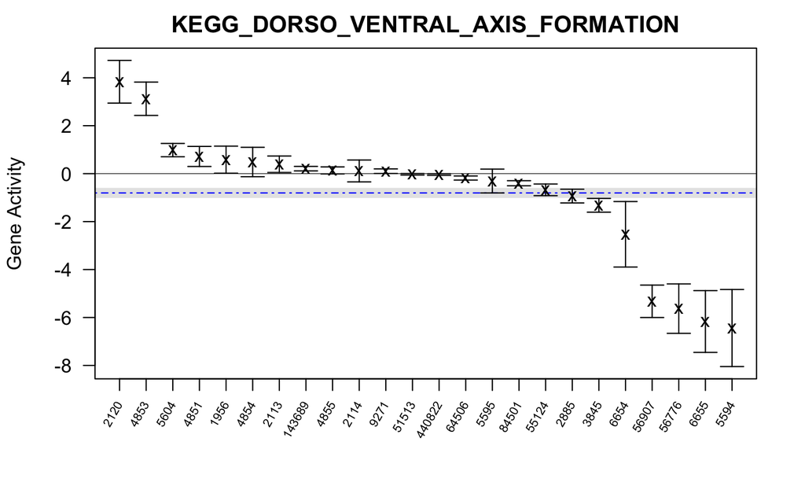

```r
plotCIsGenes(northcott_results, path.index = 107, addGrid = FALSE,
             cex.xaxis = 1.25)
```

We can see that, in the Northcott dataset, there are about 5 genes really driving the negative pathway activity. Let’s take a look at the same pathway in Robinson.

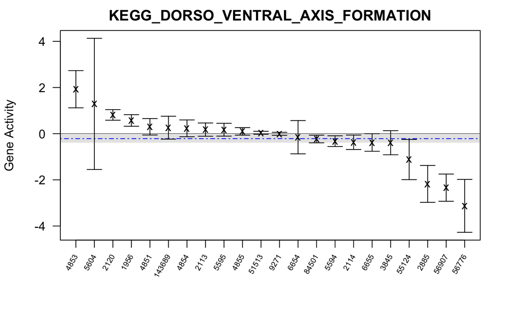

```r
plotCIsGenes(robinson_results, path.index = 107, addGrid = FALSE,
             cex.xaxis = 1.25)
```

Looks like some of the top genes are the same between datasets: `56907`, `56776` Because Entrez IDs are not particularly human-readable, we can use the same annotation package to convert these to gene symbols and gene names.

```r
AnnotationDbi::select(org.Hs.eg.db, keys = c("56907", "56776"),
                      keytype = "ENTREZID", columns = c("SYMBOL", "GENENAME"))
```

| ENTREZID | SYMBOL | GENENAME |
| --- | --- | --- |
| 56907 | SPIRE1 | spire type actin nucleation factor 1 |
| 56776 | FMN2 | formin 2 |

It looks like these two genes promote the polymerization of actin filaments.